# Course Project 2 - Analysis of Costs and Casualties in US Storm Data ’96-’11

## Results

Now present the results:

### Question 1) Across the United States, which types of events (variable EVTYPE) are most harmfull with respect to population health?

```r
# which events have most impact on populaties Health (fatalities and injuries)?
PopHealth <- data %>%
              select(EVTYPE, FATALITIES, INJURIES) %>%
              group_by(EVTYPE) %>%
              summarise(Fatalities = sum(FATALITIES), Injuries = sum(INJURIES),
                        Total = sum(FATALITIES) + sum(INJURIES)) %>%
              arrange(desc(Total))

PopHealth <- PopHealth[1:15, ]
PopHealth
```

```
## # A tibble: 15 × 4
##    EVTYPE            Fatalities Injuries Total
##    <chr>                  <dbl>    <dbl> <dbl>
##  1 TORNADO                 5633    91346 96979
##  2 EXCESSIVE HEAT          1903     6525  8428
##  3 TSTM WIND                504     6957  7461
##  4 FLOOD                    470     6789  7259
##  5 LIGHTNING                816     5230  6046
##  6 HEAT                     937     2100  3037
##  7 FLASH FLOOD              978     1777  2755
##  8 ICE STORM                 89     1975  2064
##  9 THUNDERSTORM WIND        133     1488  1621
## 10 WINTER STORM             206     1321  1527
## 11 HIGH WIND                248     1137  1385
## 12 HAIL                      15     1361  1376
## 13 HURRICANE/TYPHOON         64     1275  1339
## 14 HEAVY SNOW               127     1021  1148
## 15 WILDFIRE                  75      911   986
```

Now product a barchart that summarizes the casualties per event type. In order to present the barchart for the fatalities, injuries and total casualties the data first need to be wrangled:

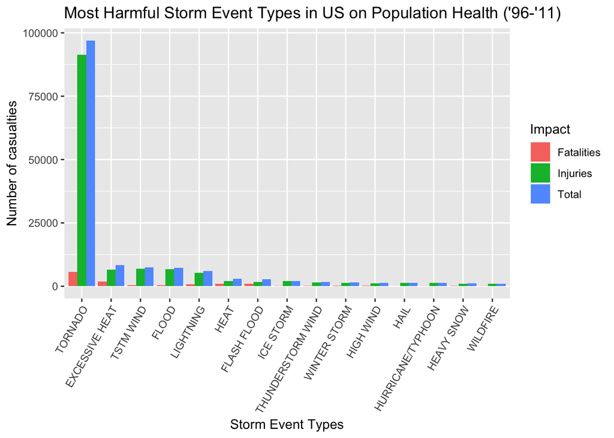

```r
lPopHealth <- PopHealth %>%
              pivot_longer(cols = c("Fatalities", "Injuries", "Total"),
                           names_to = "Impact", values_to = "Number")
lPopHealth$Impact <- as.factor(lPopHealth$Impact)
p <- ggplot(data = lPopHealth, aes(x= reorder(EVTYPE, -Number), y=Number , fill=Impact)) +
  geom_bar(stat="identity", position="dodge") +
  theme(axis.text.x = element_text(angle=60, hjust=1)) +
  ggtitle("Most Harmful Storm Event Types in US on Population Health ('96-'11)") +
  xlab("Storm Event Types") +
  ylab("Number of casualties")
p
```

### Quesion 2) Across the United States, which types of events have the greatest economic consequences.

As stated above, the economic consequences can be calculated as:

Total damage = Total damange property + Total damage crop

Total damage = PROPDMG * PROPDMGEXP + CROPDMG * CROPDMGEXP

The top 15 storm events with the greatest economic consequences are:

```r
# select Economic consequences
EcCons <- data %>%
  select(EVTYPE, PROPDMG, PROPDMGEXP, CROPDMG, CROPDMGEXP)
# change exponents
EcCons$PROPDMGEXP2 <- exponent[EcCons$PROPDMGEXP]
EcCons$CROPDMGEXP2 <- exponent[EcCons$CROPDMGEXP]
# replace NA values with 0
EcCons[is.na(EcCons)] <- 0

# calculate Economic Costs
EcCons$costs <- EcCons$PROPDMG* EcCons$PROPDMGEXP2 +
                  EcCons$CROPDMG* EcCons$CROPDMGEXP2

EcCons <- EcCons %>%
          select(EVTYPE, costs) %>%
        group_by(EVTYPE) %>%
      summarise(totalcosts = sum(costs)) %>%
  arrange(desc(totalcosts))

EcCons <- EcCons[1:15, ]
EcCons
```

```
## # A tibble: 15 × 2
##    EVTYPE              totalcosts
##    <chr>                    <dbl>
##  1 FLOOD             150319678250
##  2 HURRICANE/TYPHOON  71913712800
##  3 TORNADO            57352117607
##  4 STORM SURGE        43323541000
##  5 HAIL               18757807527
##  6 FLASH FLOOD        17562132111
##  7 DROUGHT            15018672000
##  8 HURRICANE          14610229010
##  9 RIVER FLOOD        10148404500
## 10 ICE STORM           8967041810
## 11 TROPICAL STORM      8382236550
## 12 WINTER STORM        6715441260
## 13 HIGH WIND           5908617580
## 14 WILDFIRE            5060586800
## 15 TSTM WIND           5038936340
```

Finally, plot these results:

[figure not shown]

```r
g <- ggplot(data = EcCons, aes(x= reorder(EVTYPE, -totalcosts), y =totalcosts/1000000 )) +
  geom_bar(stat="identity", position="dodge", fill="green") +
  theme(axis.text.x = element_text(angle=60, hjust=1)) +
  ggtitle("15 Storm Event Types in US with highest Economic Costs ('96-'11)") +
  xlab("Storm Event Types") +
  ylab("Economic costs in Billion USD")

g
```